# An mTurk study examining hte link between temporal discounting and abstraction

I’m interested in the link between temporal discounting and abstraction.

This is a follow-up of an earlier analysis where our result didn’t come out the way we were hoping. There was a hint of some a positive result, but it was from a post-hoc analysis.

But we never tested the quality of the data. With temporal discounting, we rely on a melioration process where we ‘titrate’ a k-value to match subjects’ ‘true’ delay discounting rate. This only works if subjects behave with a consistent k value and the melioration appears to work.

I wanted to re-do the analysis with some improvements to see if we can better detect the effect through improving the quality of our dataset.

# Post-hoc quality screening

In our algorithm, we have a discounting parameter, $k$, which indicates how much subjects prefer a reward immediately rather than later. With every trial we try to use our ‘best estimate’ of their discount rate to present a choice they’ll be indifferent to, in order to best gather information about their tipping point.

I followed a prior analysis method (Hsu, personal communication) to start off with a ‘default’ k value and then use a very simple algorithm which estimates a better discount rate - simply adjusts it up by 33% or down by 33% until we reach a trade-off point, so we get a graph like

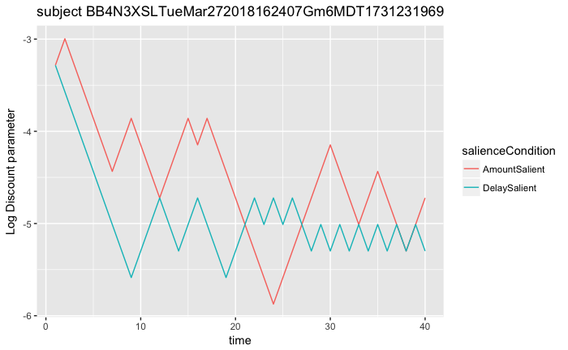

```r
subject.to.show<-unique(data.itc[ConditionCode=="BB4N3XSL", SubjectUniqueID])[[9]]
ggplot(data.itc[SubjectUniqueID==subject.to.show],
       aes(x=TrialIdItcSC,y=log(endingK),color=salienceCondition))+
  geom_line()+
  labs(y="Log Discount parameter",x="time",title=paste0("subject ",subject.to.show))
```

There is theoretically a constant discounting parameter each subject has, yet we have a varying discount parameter we use to try to set an indifference point.

With these features in mind there are two ways to test for a higher-quality dataset which we can combine to select high-quality participants.

## 1) More LargerLater choices where the k value is higher

Subjects theoretically have a constant discount rate and responses that differ according to that function, plus noise. So in trials where the ‘provisional’ k value used to set the indifference point (“`logStartingK`”) is higher, it’ll be higher *relative to subject’s true discount rate* and thus, the higher that provisional kvalue is, the more we’ll get LargerLater choices. Does this bear out?

## 2) More switches between LL and SS as the k-value approaches the true discount rate

As the run proceeds, if the melioration process is working, our k-value should approach the true discount rate and fluctuate around it. Subjects should then initially choose more of LL or SS to push the k-value from the default K to their own true K, then alternate between LL and SS once it reaches their true K.

# Analysis

## Stabilize learning rates

Do subjects stabilize their learning rates? That seems like important information to validate what we’re doing. We can measure this by adding an index at each point which indicates the number of previous consecutive trials with the same choice as the current trial. This should theoretically converge to close to 0 as we go through the task.

```
Analysis of Variance Table

Model 1: ConsecutiveChoices ~ TrialIdItcSC
Model 2: ConsecutiveChoices ~ TrialIdItcSC + I(TrialIdItcSC^2)
  Res.Df     RSS Df Sum of Sq     F    Pr(>F)
1  11518 1078533
2  11517 1076410  1    2123.4 22.72 1.898e-06 ***
---
Signif. codes:  0 ‘***’ 0.001 ‘**’ 0.01 ‘*’ 0.05 ‘.’ 0.1 ‘ ’ 1

Call:
lm(formula = ConsecutiveChoices ~ TrialIdItcSC + I(TrialIdItcSC^2),
    data = data.no.missing)

Residuals:
   Min     1Q Median     3Q    Max
-6.288 -4.996 -3.231  0.769 64.788

Coefficients:
                    Estimate Std. Error t value Pr(>|t|)
(Intercept)        6.3650353  0.2843153  22.387  < 2e-16 ***
TrialIdItcSC       0.1154039  0.0319815   3.608 0.000309 ***
I(TrialIdItcSC^2) -0.0036057  0.0007565  -4.766  1.9e-06 ***
---
Signif. codes:  0 ‘***’ 0.001 ‘**’ 0.01 ‘*’ 0.05 ‘.’ 0.1 ‘ ’ 1

Residual standard error: 9.668 on 11517 degrees of freedom
Multiple R-squared:  0.00346,   Adjusted R-squared:  0.003287
F-statistic:    20 on 2 and 11517 DF,  p-value: 2.143e-09
```

A quadratic model fits the data significantly better than a linear model, and suggests a rise in consecutive trial from the start until point 16 and a fall thereafter. Subjects first picking items randomly to ‘try it out’, then settling on a strategy as they move on, and picking a set k value, and then moving to waver between LL and SS as our provisional k approaches their own true discount rate would match this pattern.

The decline occurs, but it’s small:

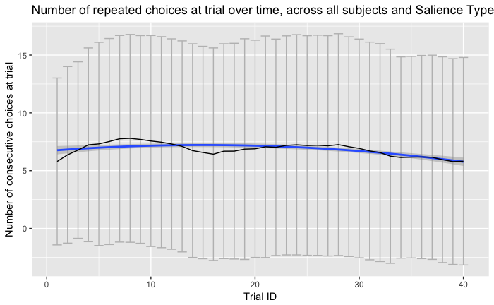

## K logStartingK and LargerLater

[output not shown]

[output cut: 157 more lines]

[output not shown]

We can see here that as the logK Value increases, we’re more likely to see the subject choose the LargerLater item.

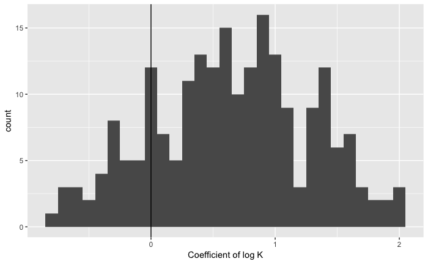

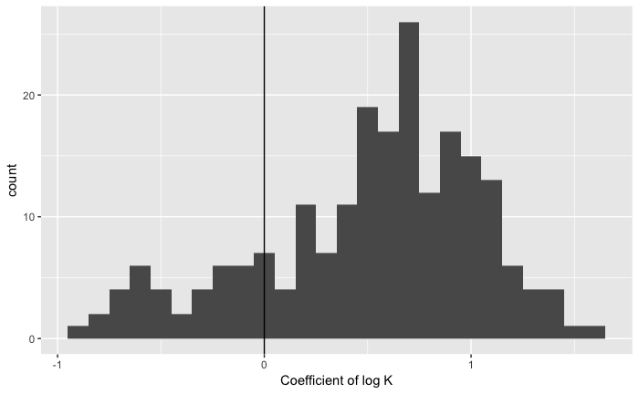

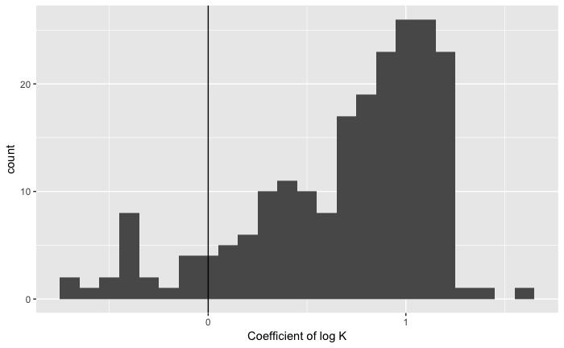

```r
subjs.to.include<-getWellPerformingSubjs(data.itc)
```

```
..........
```

[output not shown]

```
..........
```

[output not shown]

```
..............
```

[output not shown]

```
...
```

[output not shown]

```
.
```

[output not shown]

```
.....
```

[output not shown]

[output not shown]

[output not shown]

```
.....
```

[output not shown]

```
................
```

[output not shown]

```
.....
```

[output not shown]

```
......
```

[output not shown]

[output not shown]

[output not shown]

```
.....
```

[output not shown]

```
..............
```

[output not shown]

```
...........
```

[output not shown]

```
.......
```

[output not shown]

```
........
```

[output not shown]

```
...
```

[output not shown]

```
....
```

[output not shown]

```
.
```

[output not shown]

```
......
```

### H1 Construal level

1. A Construal Level manipulation has an effect on temporal discounting, such that more abstract construal level manipulations predict lower rates of temporal discounting

```
Linear mixed model fit by REML ['lmerMod']
Formula: AbstractionLevel ~ LogKIndiff + ChoiceIsLL + (1 + ChoiceIsLL |
    SubjectUniqueID) + (1 | salienceCondition)
   Data: data.itc.bestsubj
Control: lmerControl(optimizer = "Nelder_Mead")

REML criterion at convergence: 27188.3

Scaled residuals:
     Min       1Q   Median       3Q      Max
-1.86223 -0.88919 -0.06765  0.84774  1.87774

Random effects:
 Groups            Name           Variance Std.Dev. Corr
 SubjectUniqueID   (Intercept)    0.021234 0.14572
                   ChoiceIsLLTRUE 0.122529 0.35004  -1.00
 salienceCondition (Intercept)    0.008122 0.09012
 Residual                         1.221229 1.10509
Number of obs: 8902, groups:  SubjectUniqueID, 113; salienceCondition, 2

Fixed effects:
                Estimate Std. Error t value
(Intercept)     2.480872   0.067094   36.98
LogKIndiff     -0.001575   0.001032   -1.53
ChoiceIsLLTRUE  0.040640   0.040662    1.00

Correlation of Fixed Effects:
            (Intr) LgKInd
LogKIndiff   0.000
ChcIsLLTRUE -0.257  0.071
```

```
refitting model(s) with ML (instead of REML)
```

```
Data: data.itc.bestsubj
Models:
choicemodel.base.VarySubSlope: AbstractionLevel ~ LogKIndiff + (1 + ChoiceIsLL | SubjectUniqueID) +
choicemodel.base.VarySubSlope:     LogKIndiff + (1 | salienceCondition)
choicemodel.choice.VarySubSlope: AbstractionLevel ~ LogKIndiff + ChoiceIsLL + (1 + ChoiceIsLL |
choicemodel.choice.VarySubSlope:     SubjectUniqueID) + (1 | salienceCondition)
                                Df   AIC   BIC logLik deviance  Chisq Chi Df
choicemodel.base.VarySubSlope    7 27183 27232 -13584    27169
choicemodel.choice.VarySubSlope  8 27184 27241 -13584    27168 0.9905      1
                                Pr(>Chisq)
choicemodel.base.VarySubSlope
choicemodel.choice.VarySubSlope     0.3196
```

# Exploratory

I subsequently tried examining a smaller subset: *only* subjects who were in the Concrete First condition (as in Yi et al., 2017), *and* whose construal and ITC trials were blocked, rather than interleaved.

```
Data: data.itc.bestsubj[TaskArrangementBlocked == TRUE & BlockDesignConcreteFirst ==  ...
Models:
choicemodel.base.VarySubSlope.blockedconcrete.bestsubjs: AbstractionLevel ~ scale(LogKIndiff) + salienceCondition + (1 +
choicemodel.base.VarySubSlope.blockedconcrete.bestsubjs:     ChoiceIsLL | SubjectUniqueID)
choicemodel.choice.VarySubSlope.blockedconcrete.bestsubjs: AbstractionLevel ~ ChoiceIsLL + scale(LogKIndiff) + salienceCondition +
choicemodel.choice.VarySubSlope.blockedconcrete.bestsubjs:     (1 + ChoiceIsLL | SubjectUniqueID)
                                                          Df    AIC    BIC  logLik deviance  Chisq Chi Df Pr(>Chisq)
choicemodel.base.VarySubSlope.blockedconcrete.bestsubjs    7 6320.7 6360.1 -3153.3   6306.7
choicemodel.choice.VarySubSlope.blockedconcrete.bestsubjs  8 6322.2 6367.2 -3153.1   6306.2 0.5228      1     0.4696
```

# Further followup

One thing that came out out of our previous test was whether the Abstract-Concrete ordering is really an important interaction variable for assessing the effect of Abstraction Level.

Can we run an interaction model? Let’s include both block design conditions (AbstractFirst and ConcreteFirst), and see if the interaction term is significant.

```
refitting model(s) with ML (instead of REML)
```

```
Data: data.itc.bestsubj[TaskArrangementBlocked == TRUE & (BlockDesignConcreteFirst ==  ...
Models:
choicemodel.base.VarySubSlope.blockedconcrete: AbstractionLevel ~ BlockDesignConcreteFirst + scale(LogKIndiff) +
choicemodel.base.VarySubSlope.blockedconcrete:     salienceCondition + (1 + ChoiceIsLL | SubjectUniqueID)
choicemodel.choice.VarySubSlope.blockedconcrete: AbstractionLevel ~ ChoiceIsLL * BlockDesignConcreteFirst + scale(LogKIndiff) +
choicemodel.choice.VarySubSlope.blockedconcrete:     salienceCondition + (1 + ChoiceIsLL | SubjectUniqueID)
                                                Df   AIC   BIC  logLik deviance  Chisq Chi Df Pr(>Chisq)
choicemodel.base.VarySubSlope.blockedconcrete    8 14312 14364 -7148.3    14296
choicemodel.choice.VarySubSlope.blockedconcrete 10 14316 14380 -7148.0    14296 0.5904      2     0.7444
Linear mixed model fit by REML ['lmerMod']
Formula: AbstractionLevel ~ ChoiceIsLL * BlockDesignConcreteFirst + scale(LogKIndiff) +      salienceCondition + (1 + ChoiceIsLL | SubjectUniqueID)
   Data: data.itc.bestsubj[TaskArrangementBlocked == TRUE & (BlockDesignConcreteFirst ==      TRUE | BlockDesignAbstractFirst == TRUE)]
Control: lmerControl(optimizer = "Nelder_Mead")

REML criterion at convergence: 14325.5

Scaled residuals:
    Min      1Q  Median      3Q     Max
-1.6653 -1.0467  0.1401  0.7587  1.5963

Random effects:
 Groups          Name           Variance Std.Dev. Corr
 SubjectUniqueID (Intercept)    0.01627  0.1276
                 ChoiceIsLLTRUE 0.08439  0.2905   -1.00
 Residual                       1.22723  1.1078
Number of obs: 4684, groups:  SubjectUniqueID, 59

Fixed effects:
                                            Estimate Std. Error t value
(Intercept)                                  2.45070    0.04110   59.63
ChoiceIsLLTRUE                              -0.02031    0.06669   -0.30
BlockDesignConcreteFirstTRUE                -0.02552    0.05511   -0.46
scale(LogKIndiff)                           -0.02026    0.01717   -1.18
salienceConditionDelaySalient                0.12164    0.03267    3.72
ChoiceIsLLTRUE:BlockDesignConcreteFirstTRUE  0.07264    0.10078    0.72

Correlation of Fixed Effects:
            (Intr) ChILLTRUE BDCFTR s(LKI) slnCDS
ChcIsLLTRUE -0.743
BlckDCFTRUE -0.617  0.544
scl(LgKInd) -0.008  0.019    -0.006
slncCndtnDS -0.422  0.032     0.010  0.002
CILLTRUE:BD  0.488 -0.661    -0.796 -0.014 -0.012
```

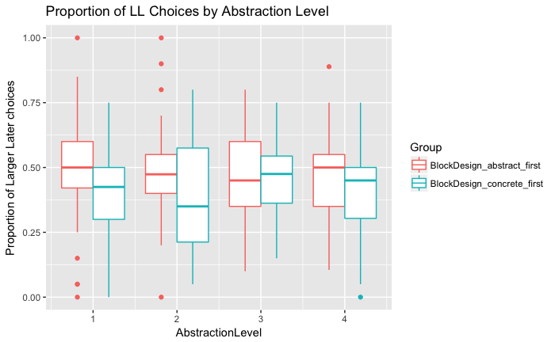

Base using Best Subjects:

[output not shown]

```
refitting model(s) with ML (instead of REML)
```

```
Data: data.itc.bestsubj[TaskArrangementBlocked == TRUE & (BlockDesignConcreteFirst ==  ...
Models:
choicemodel.base.VarySubSlope.blockedconcrete: AbstractionLevel ~ BlockDesignConcreteFirst + scale(LogKIndiff) +
choicemodel.base.VarySubSlope.blockedconcrete:     salienceCondition + (1 + ChoiceIsLL | SubjectUniqueID)
choicemodel.choice.VarySubSlope.blockedconcrete: AbstractionLevel ~ ChoiceIsLL * BlockDesignConcreteFirst + scale(LogKIndiff) +
choicemodel.choice.VarySubSlope.blockedconcrete:     salienceCondition + (1 + ChoiceIsLL | SubjectUniqueID)
                                                Df   AIC   BIC  logLik deviance  Chisq Chi Df Pr(>Chisq)
choicemodel.base.VarySubSlope.blockedconcrete    8 14312 14364 -7148.3    14296
choicemodel.choice.VarySubSlope.blockedconcrete 10 14316 14380 -7148.0    14296 0.5904      2     0.7444
```

Interaction using Best Subjects:

```
Linear mixed model fit by REML ['lmerMod']
Formula: AbstractionLevel ~ ChoiceIsLL * BlockDesignConcreteFirst + scale(LogKIndiff) +      salienceCondition + (1 + ChoiceIsLL | SubjectUniqueID)
   Data: data.itc.bestsubj[TaskArrangementBlocked == TRUE & (BlockDesignConcreteFirst ==      TRUE | BlockDesignAbstractFirst == TRUE)]
Control: lmerControl(optimizer = "Nelder_Mead")

REML criterion at convergence: 14325.5

Scaled residuals:
    Min      1Q  Median      3Q     Max
-1.6653 -1.0467  0.1401  0.7587  1.5963

Random effects:
 Groups          Name           Variance Std.Dev. Corr
 SubjectUniqueID (Intercept)    0.01627  0.1276
                 ChoiceIsLLTRUE 0.08439  0.2905   -1.00
 Residual                       1.22723  1.1078
Number of obs: 4684, groups:  SubjectUniqueID, 59

Fixed effects:
                                            Estimate Std. Error t value
(Intercept)                                  2.45070    0.04110   59.63
ChoiceIsLLTRUE                              -0.02031    0.06669   -0.30
BlockDesignConcreteFirstTRUE                -0.02552    0.05511   -0.46
scale(LogKIndiff)                           -0.02026    0.01717   -1.18
salienceConditionDelaySalient                0.12164    0.03267    3.72
ChoiceIsLLTRUE:BlockDesignConcreteFirstTRUE  0.07264    0.10078    0.72

Correlation of Fixed Effects:
            (Intr) ChILLTRUE BDCFTR s(LKI) slnCDS
ChcIsLLTRUE -0.743
BlckDCFTRUE -0.617  0.544
scl(LgKInd) -0.008  0.019    -0.006
slncCndtnDS -0.422  0.032     0.010  0.002
CILLTRUE:BD  0.488 -0.661    -0.796 -0.014 -0.012
```

```
refitting model(s) with ML (instead of REML)
```

```
Data: data.itc.bestsubj[TaskArrangementBlocked == TRUE & (BlockDesignConcreteFirst ==  ...
Models:
choicemodel.base.VarySubSlope.blockedconcrete: AbstractionLevel ~ BlockDesignConcreteFirst + scale(LogKIndiff) +
choicemodel.base.VarySubSlope.blockedconcrete:     salienceCondition + (1 + ChoiceIsLL | SubjectUniqueID)
choicemodel.choice.VarySubSlope.blockedconcrete: AbstractionLevel ~ ChoiceIsLL * BlockDesignConcreteFirst + scale(LogKIndiff) +
choicemodel.choice.VarySubSlope.blockedconcrete:     salienceCondition + (1 + ChoiceIsLL | SubjectUniqueID)
                                                Df   AIC   BIC  logLik deviance  Chisq Chi Df Pr(>Chisq)
choicemodel.base.VarySubSlope.blockedconcrete    8 14312 14364 -7148.3    14296
choicemodel.choice.VarySubSlope.blockedconcrete 10 14316 14380 -7148.0    14296 0.5904      2     0.7444
```